# Cuisine Score by Alcohol Consumption

10/25/2020

## Cuisine Score by Alcohol Consumption

```r
getfile_1 <- getURL("https://raw.githubusercontent.com/fivethirtyeight/data/master/alcohol-consumption/drinks.csv")
alcohol <- read.csv(text = getfile_1)
```

A separate data set was collected by the World Health Organization cataloging the annual alcohol consumption of nations across the globe.

```r
getfile_2 <- getURL("https://raw.githubusercontent.com/fivethirtyeight/data/master/food-world-cup/food-world-cup-data.csv")
food <- read.csv(text = getfile_2, header=FALSE, stringsAsFactors=FALSE, na.strings = c("N/A",""))
```

## Data Cleaning

Header configuration is not importing correctly for the food data set. As a workaround, the data is imported without headers, and the appropriate naming is extracted from the first row.

```r
headers <- food[1,]
headers_new <- str_replace(str_extract(headers, "(([:upper:])[:lower:]+[:punct:]?)$"), "[:punct:]", "")
food <- slice(food,-1)
colnames(food) <- headers_new
colnames(food)[1:3] <- c("respondant_id", "international_cuisine_knowledge", "international_cuisine_interest")
```

## Data Manipulation

Pivot

```r
food_pivot <- food %>%
  pivot_longer(cols = Algeria:Ireland, names_to = "country", values_to = "rating", values_drop_na = TRUE)%>%
  mutate(rating = as.numeric(rating))
```

Aggregate

```r
food_rating_agg <- food_pivot %>%
  group_by(country)%>%
  summarise(avg_rating = mean(rating))
```

Now we can join the tables for comparison

```r
food_drink <- food_rating_agg%>%
  inner_join(alcohol)
```

## Cuisine Score by Total Alcohol Consumption

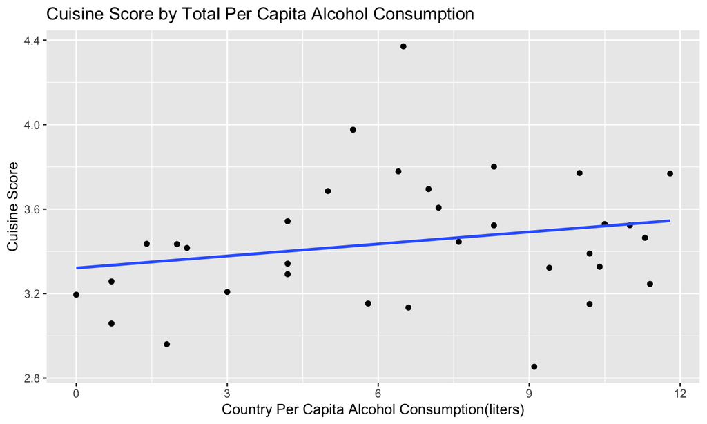

## Correlation

```r
food_drink %>% summarise(cor(total_litres_of_pure_alcohol,avg_rating))
```

```
## # A tibble: 1 x 1
##   `cor(total_litres_of_pure_alcohol, avg_rating)`
##                                             <dbl>
## 1                                           0.223
```

## Summary

With the below p-value, the results are not significant enough to reject the null hypothesis that the correlation is 0.

```r
summary(lm(food_drink$total_litres_of_pure_alcohol ~ food_drink$avg_rating))
```

```
##
## Call:
## lm(formula = food_drink$total_litres_of_pure_alcohol ~ food_drink$avg_rating)
##
## Residuals:
##    Min     1Q Median     3Q    Max
## -5.829 -2.540  0.080  3.795  5.438
##
## Coefficients:
##                       Estimate Std. Error t value Pr(>|t|)
## (Intercept)             -2.534      7.114  -0.356    0.724
## food_drink$avg_rating    2.618      2.057   1.272    0.213
##
## Residual standard error: 3.58 on 31 degrees of freedom
## Multiple R-squared:  0.04963,    Adjusted R-squared:  0.01897
## F-statistic: 1.619 on 1 and 31 DF,  p-value: 0.2127
```

## Multiple Regression

The WHO data has additional parameters broken out by alcohol type that we can also test.

```r
summary(lm(food_drink$avg_rating ~ food_drink$spirit_servings +food_drink$beer_servings +food_drink$wine_servings))
```

```
##
## Call:
## lm(formula = food_drink$avg_rating ~ food_drink$spirit_servings +
##     food_drink$beer_servings + food_drink$wine_servings)
##
## Residuals:
##      Min       1Q   Median       3Q      Max
## -0.37173 -0.15955 -0.01867  0.04562  0.94176
##
## Coefficients:
##                              Estimate Std. Error t value Pr(>|t|)
## (Intercept)                 3.2134728  0.0987665  32.536  < 2e-16 ***
## food_drink$spirit_servings  0.0022672  0.0007650   2.963  0.00602 **
## food_drink$beer_servings   -0.0001268  0.0005936  -0.214  0.83233
## food_drink$wine_servings    0.0005538  0.0004630   1.196  0.24137
## ---
## Signif. codes:  0 '***' 0.001 '**' 0.01 '*' 0.05 '.' 0.1 ' ' 1
##
## Residual standard error: 0.2739 on 29 degrees of freedom
## Multiple R-squared:  0.2813, Adjusted R-squared:  0.207
## F-statistic: 3.784 on 3 and 29 DF,  p-value: 0.02093
```

```r
panel.hist <- function(x, ...)
{
    usr <- par("usr"); on.exit(par(usr))
    par(usr = c(usr[1:2], 0, 1.5) )
    h <- hist(x, plot = FALSE)
    breaks <- h$breaks; nB <- length(breaks)
    y <- h$counts; y <- y/max(y)
    rect(breaks[-nB], 0, breaks[-1], y, col = "cyan", ...)
}
```

```r
panel.cor <- function(x, y, digits = 2, prefix = "", cex.cor, ...)
{
    usr <- par("usr"); on.exit(par(usr))
    par(usr = c(0, 1, 0, 1))
    r <- abs(cor(x, y))
    txt <- format(c(r, 0.123456789), digits = digits)[1]
    txt <- paste0(prefix, txt)
    if(missing(cex.cor)) cex.cor <- 0.8/strwidth(txt)
    text(.5, .5, txt, cex = cex.cor * r)
}
```

## Comparing Variables

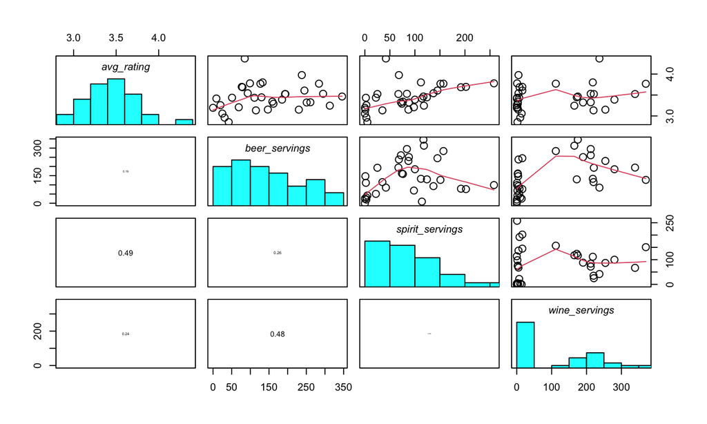

```r
pairs(food_drink[2:5], panel = panel.smooth,lower.panel = panel.cor,
      cex = 1.5, pch = 1, bg = "light blue", horOdd=TRUE,
      diag.panel = panel.hist, cex.labels = 1, font.labels = 3)
```

## Multiple Regression Results

The Spirit Servings variable is doing the heavy lifting, so we move forward without the remaining variables as they are not contributing.

```r
summary(lm(food_drink$avg_rating ~ food_drink$spirit_servings))
```

```
##
## Call:
## lm(formula = food_drink$avg_rating ~ food_drink$spirit_servings)
##
## Residuals:
##      Min       1Q   Median       3Q      Max
## -0.40793 -0.12861 -0.05565  0.11925  1.02401
##
## Coefficients:
##                             Estimate Std. Error t value Pr(>|t|)
## (Intercept)                3.2500582  0.0778465  41.750  < 2e-16 ***
## food_drink$spirit_servings 0.0023061  0.0007335   3.144  0.00366 **
## ---
## Signif. codes:  0 '***' 0.001 '**' 0.01 '*' 0.05 '.' 0.1 ' ' 1
##
## Residual standard error: 0.2721 on 31 degrees of freedom
## Multiple R-squared:  0.2417, Adjusted R-squared:  0.2173
## F-statistic: 9.884 on 1 and 31 DF,  p-value: 0.003661
```

## Cuisine Score by Spirit Consumption

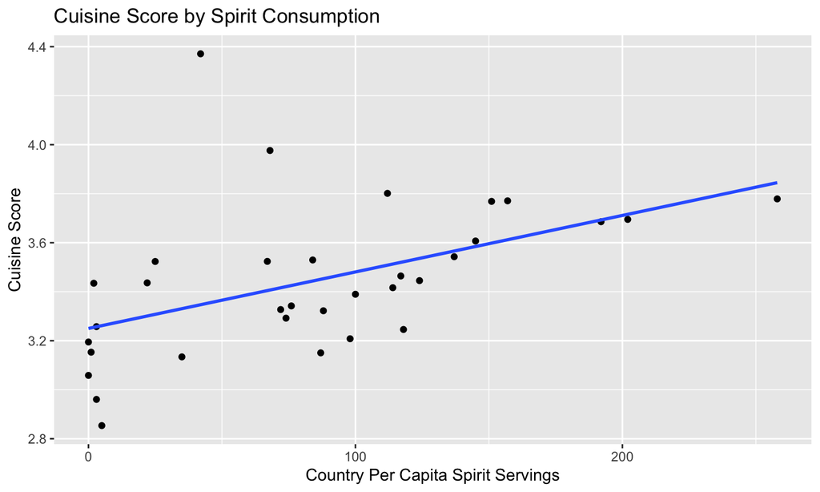

```r
cor.test(food_drink$avg_rating, food_drink$spirit_servings)
```

```
##
##  Pearson's product-moment correlation
##
## data:  food_drink$avg_rating and food_drink$spirit_servings
## t = 3.1438, df = 31, p-value = 0.003661
## alternative hypothesis: true correlation is not equal to 0
## 95 percent confidence interval:
##  0.1785006 0.7143991
## sample estimates:
##       cor
## 0.4916791
```

## Conditions

[figure not shown]

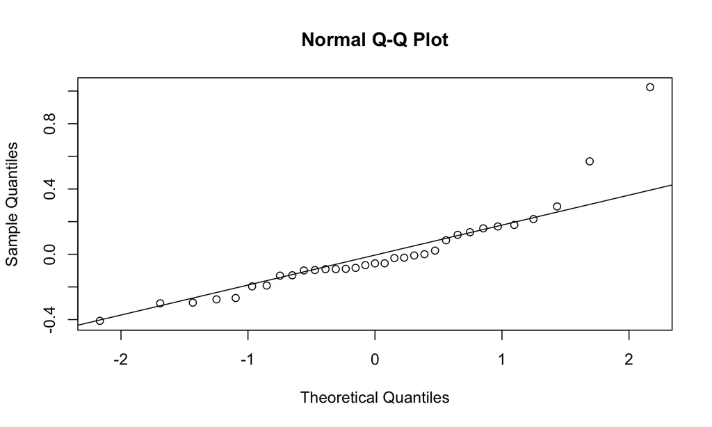

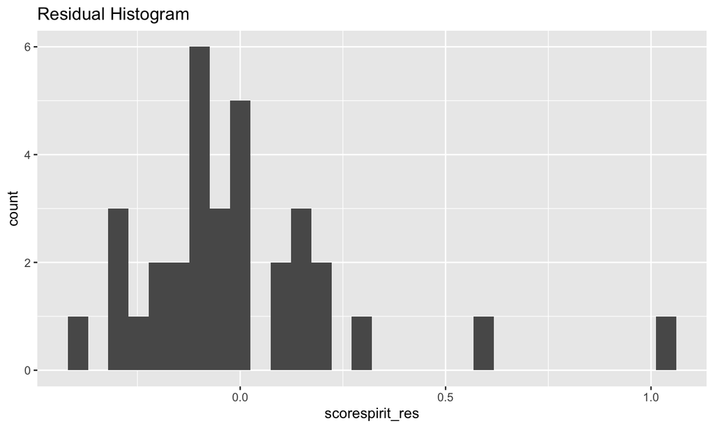

## Conclusion

- Data Set of Cuisine Ranking is small, just barely above what may be considered appropriate(>30).
- Only significant variable is spirit serving but the data is heavily skewed.
- Residual variability is not evenly distributed, and normality is questionable.

**Although the results are interesting and some of the statistics are tempting to trust, I believe we cannot make reasonable predictions of how Americans would rate various ethic cuisines base of the country of origins propensity towards alcohol.**